# Машинное обучение. ВМК МГУ

## Практическое задание 5: Линейные модели, часть 2: Классификация

### Важно! О формате сдачи

- Практически все задания в этой части оцениваются по системе кросс-рецензирования.
- Задания, в котором надо реализовывать свой код и послать в систему, выделены здесь и в pdf отдельно
- В этом ноутбуке есть задание на unit-тестирование
- При решении ноутбука используйте данный шаблон. Не нужно удалять текстовые ячейки c разметкой частей ноутбука и формулировками заданий. Добавлять свои ячейки, при необходимости, конечно можно
- Везде, где в формулировке задания есть какой-либо вопрос (или просьба вывода), необходимо прописать ответ в ячейку (код или markdown).
- Наличие кода решения обязательно. Письменные ответы на вопросы без сопутствующего кода оцениваются в 0 баллов.
- Если в ячейке написана фраза "Вывод"/"Ответ на вопрос" итд, то ожидается ответ в виде текста (можете добавить ячейки с кодом, если считаете это необходимым, но это необязательно). Если в ячейке написано "Your code here" и пр. , то ожидается ответ в виде кода (можете добавить ячейки с кодом, если считаете это необходимым, но это необязательно). Если есть и ячейка с фразой "Вывод", и ячейка с фразой "Your code here", то в ответе ожидается и код, и текст

Цель данного задания:

- Узнать, что такое переобучение и как с ним бороться в линейных моделях;
- Научиться работать с разными типами признаков;
- Понять, чем отличаются разные регуляризаторы;
- Приятно провести осенний вечер, предсказывая дождь.

При выполнении данного задания необходимо последовательно запустить все ячейки ноутбука и ответить на $16$ вопросов. Ответы на вопросы будут проверены в рамках кросс-ревью. Всего за ответы на вопросы можно получить $28$ баллов + $2$ бонус

### *Примерное время выполнения (execution time/время выполнения, если нажать run all) всех ячеек ноутбука при правильной реализации: 30 минут *

## Подготовка рабочей среды

Сначала установим нужные нам версии библиотек. Мы гарантируем, что в данных версиях задание будет корректно отрабатывать.

После установки нужных версий, **возможно,** нужно перезагрузить среду (runtime), но скорее всего вам это не понадобится

На скачивание файла и установку понадобится не более 5 минут.

**Важно!** Устанавливать нужные версии нужно каждый раз, когда создается новый рантайм. Например, если вы 2 часа подряд делаете это задание, то подготовить библиотеки достаточно 1 раз. Но если вы, например, начали в понедельник, затем закрыли/выключили ноутбук, то при продолжении в среду, вам нужно будет запустить рантайм заново и следовательно заново установить библиотеки.

**Важно!** Если вы предпочитаете делать практические задания на своем личном ноутбуке, то проверьте, что вы установили рабочее окружение в [соответствии с гайдом](https://github.com/MSU-ML-COURSE/ML-COURSE-23-24/blob/main/tutorials/Туториал%20по%20установке%20рабочего%20окружения%20в%20Python%20для%20решения%20задач.pdf)

```python
# !!! Данный блок будет работать только в Google-Colab !!!
# Устанавливаем урезанную версию requeirements.txt для ускорения установки
# Если будут всплывать ошибки о несовместимости библиотек, то ничего страшного
# На это задание они не влияют

! gdown 1pIw8GdGKY6fZ_XNPc6snimdV6lbXJ199
! pip install -r /content/requirements_small.txt
```

[output not shown]

```python
import catboost
assert(catboost.__version__ == '1.2.1')
```

Теперь можно приступать к выполнению задания! :)

```python
import numpy as np
import pandas as pd
import matplotlib.pyplot as plt
import seaborn as sns
import warnings
warnings.simplefilter("ignore")
sns.set(style="darkgrid")
%matplotlib inline
```

## Часть 0. Юнит-тестирование (12 баллов)

Ниже импортируются классы, которые необходимо реализовать самостоятельно. Правильность реализации проверяется юнит-тестами. Максимально за юнит-тесты можно получить $12$ баллов. Шаблон для классов находится в отдельной вкладке.

**После того, как вы локально реализовали и протестировали модуль Task.py, загрузите его в сессионное хранилище: нажмите знак папки слева, затем знак загрузки. Будьте внимательны, по окончании сессии хранилище очистится -- вам нужно будет заново загрузить соответствующие модули**

**Обратите внимание!** Если Ваша реализация счётчиков работает очень долго (скажем, больше 2 секунд: можно посмотреть в системе, сколько оно тестировалось), то вероятнее всего, Вы плохо векторизовали код, и ваш ноутбук, перед вопросом 16, будет долго работать. Попробуйте использовать `np.vectorize`

```python
from Task import MyOneHotEncoder, SimpleCounterEncoder, FoldCounters
```

## Часть 1. Классификация

Напомним, что бинарная линейная классификация с классами $0$ и $1$ — это модель следующего вида: $a(x)= \begin{cases} 1, & \langle w, x \rangle + b > 0; \\ 0, & \text{иначе.} \end{cases}$

где $w \in \mathbb{R}^d$, $b \in \mathbb{R}$. В логистической регрессии $p(x) = \frac{1}{1 + e^{-[\langle w, x \rangle + b]}}$ интерпретируется как вероятность принадлежности к первому классу. Если объект $x$ принадлежит классу $1$ с вероятностью $p(x)$, то правдоподобие записывается в виде $\prod_{i=1}^{n} p(x_i)^{y_i} \cdot \left( 1 - p(x_i) \right)^{1 - y_i}$. Обучить логистическую регрессию означает найти параметры $w$ и $b$, которые максимизируют указанное правдоподобие. Что эквивалентно минимизации $- \sum_{i=1}^n y_i \log p(x_i) + (1 - y_i) \log (1 - p(x_i))$. Указанная функция потерь называет логистической (или логлосс).

По тем же причинам, что и в линейной регрессии, к логистической функции потерь добавляется регуляризация (стандартно это $l_2$).

### **Вопрос 1** (1 балл)

Можно ли использовать $𝑙_1$ регуляризацию в логистической регрессии?

Рассмотрим пару модельных примеров, в которых целевая переменная $y$ линейно зависит от двух независимых величин $x_1$ и $x_2$, плюс случайный шум.

```python
np.random.seed(1)
X = np.random.randn(100, 2)
Y = np.random.randn(100) * 1. + X[:, 0] * 3 - X[:, 1] * 0.12
Y = np.where(Y > 0, 1, 0)
```

Обучим логистическую регрессию, двумя методами LBFGS и Newton-CG. Для простоты восприятия, можно считать, что первый похож на градиентный спуск, а второй на метод Ньютона

```python
from sklearn.linear_model import LogisticRegression

clf_lbfgs = LogisticRegression(C=1, solver='lbfgs', max_iter=1, warm_start=True, fit_intercept=False)
clf_newton_cg = LogisticRegression(C=1, solver='newton-cg', max_iter=1, warm_start=True, fit_intercept=False)

coefs_lbfgs = []
coefs_nc = []

for it in range(1000):
    clf_lbfgs.fit(X, Y)
    coefs_lbfgs.append(clf_lbfgs.coef_[0])
    clf_newton_cg.fit(X, Y)
    coefs_nc.append(clf_newton_cg.coef_[0])

coefs_lbfgs = np.array(coefs_lbfgs)
coefs_nc = np.array(coefs_nc)
```

```python
x1 = np.linspace(0.5, 3.5, 1000)
x2 = np.linspace(-0.5, -0.1, 1000)
X1, X2 = np.meshgrid(x1, x2)

def loss(X1, X2, X, Y):
    def sigmoid(x):
        return 1 / (1 + np.exp(-x))
    p = sigmoid(X1[None] * X[:, 0, None, None] + X2[None] * X[:, 1, None, None]) # 100, 200, 200
    return -np.sum(Y[:, None, None] * np.log(p) + (1 - Y[:, None, None]) * np.log(1 - p), axis=0) + 0.5 * (X1**2 + X2**2)

Z = loss(X1, X2, X, Y)
```

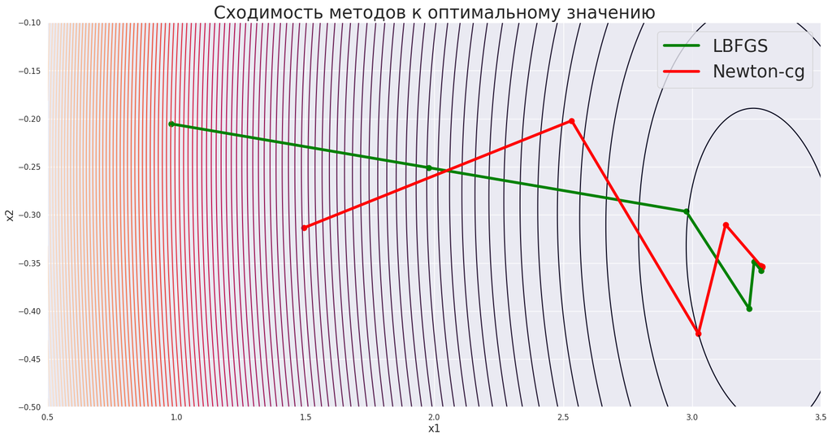

```python
sns.set(style="darkgrid")
plt.figure(figsize=(20, 10))
plt.contour(X1, X2, Z, levels=100)
plt.plot(coefs_lbfgs[:, 0], coefs_lbfgs[:, 1], color="green", linewidth=4, label="LBFGS")
plt.scatter(coefs_lbfgs[:, 0], coefs_lbfgs[:, 1], color="green", s=60)
plt.plot(coefs_nc[:, 0], coefs_nc[:, 1], color="red", linewidth=4, label="Newton-cg")
plt.scatter(coefs_nc[:, 0], coefs_nc[:, 1], color="red", s=60)
plt.legend(fontsize=25)
plt.xlabel("x1", size=15)
plt.ylabel("x2", size=15)
plt.title("Сходимость методов к оптимальному значению", size=25)
plt.show()
```

Рассмотрим второй пример. **Внимание**, здесь $x_2$ уже из другого распределения!

```python
np.random.seed(1)
X = np.hstack((np.random.randn(100, 1), np.random.uniform(7, 12, (100, 1))))
Y = np.random.randn(100) * 1. + X[:, 0] * 3 - X[:, 1] * 0.12
Y = np.where(Y > 0, 1, 0)
```

```python
clf_lbfgs = LogisticRegression(C=1, solver='lbfgs', max_iter=1, warm_start=True, fit_intercept=False)
clf_newton_cg = LogisticRegression(C=1, solver='newton-cg', max_iter=1, warm_start=True, fit_intercept=False)

coefs_lbfgs = []
coefs_nc = []

for it in range(1000):
    clf_lbfgs.fit(X, Y)
    coefs_lbfgs.append(clf_lbfgs.coef_[0])
    clf_newton_cg.fit(X, Y)
    coefs_nc.append(clf_newton_cg.coef_[0])

coefs_lbfgs = np.array(coefs_lbfgs)
coefs_nc = np.array(coefs_nc)

x1 = np.linspace(0, 3.5, 1000)
x2 = np.linspace(0.01, -0.1, 1000)
X1, X2 = np.meshgrid(x1, x2)
Z = loss(X1, X2, X, Y)
```

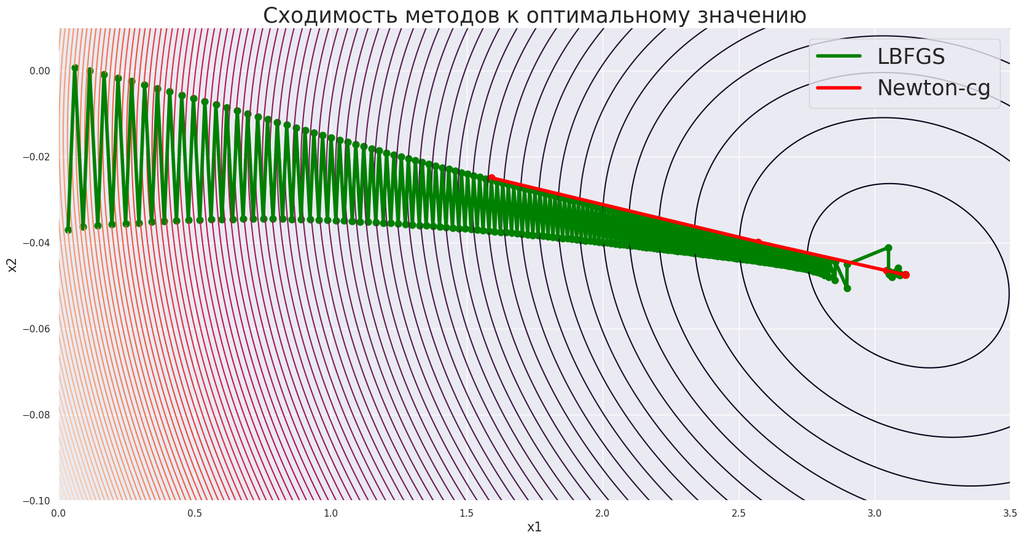

```python
sns.set(style="darkgrid")
plt.figure(figsize=(20, 10))
plt.contour(X1, X2, Z, levels=100)
plt.plot(coefs_lbfgs[:, 0], coefs_lbfgs[:, 1], color="green", linewidth=4, label="LBFGS")
plt.scatter(coefs_lbfgs[:, 0], coefs_lbfgs[:, 1], color="green", s=60)
plt.plot(coefs_nc[:, 0], coefs_nc[:, 1], color="red", linewidth=4, label="Newton-cg")
plt.scatter(coefs_nc[:, 0], coefs_nc[:, 1], color="red", s=60)
plt.legend(fontsize=25)
plt.xlabel("x1", size=15)
plt.ylabel("x2", size=15)
plt.title("Сходимость методов к оптимальному значению", size=25)
plt.show()
```

### **Вопрос 2** (2 балла)

Как видим, метод LBFGS плохо работает на неотмасштабированных данных. Это общее свойство всех методов первого порядка (т.е. использующих только первую производную). Ньютоновские же методы хорошо справляются с подобными ситуациями. В таком случае, почему LBFGS является методом по умолчанию, а не Newton-CG?

*Ваш ответ здесь* Вообще стараются обойтись квазиньютоновским подходом, так как вычилсять гессиана напрямую достаточно сложная задача.

Давайте рассмотрим ещё один модельный пример.

$y(x_1, x_2)= \begin{cases} 0, & x_1 + x_2 < 5; \\ 1, & \text{иначе.} \end{cases}$

Сгенерируем данные и выучим логистическую регрессию, визуализировав полученный результат.

```python
np.random.seed(1)
X1 = np.random.uniform(0, 5, 100)
X2 = np.random.uniform(0, 5, 100)
X = np.hstack((X1[:, None], X2[:, None]))
Y = np.where(X1 + X2 < 5, 0, 1)
```

```python
clf = LogisticRegression(penalty='l2')
clf.fit(X, Y)
```

```
LogisticRegression()
```

```python
from matplotlib.colors import ListedColormap

def plot_separating_surface(X, y, cls, view_support=False):
    x_min = min(X[:, 0]) - 0.1
    x_max = max(X[:, 0]) + 0.1
    y_min = min(X[:, 1]) - 0.1
    y_max = max(X[:, 1]) + 0.1
    h = 0.005
    cm = plt.cm.RdBu
    cm_bright = ListedColormap(['#FF0000', '#0000FF'])

    xx, yy = np.meshgrid(np.arange(x_min, x_max, h),
                             np.arange(y_min, y_max, h))
    Z = cls.predict(np.c_[xx.ravel(), yy.ravel()])

    plt.figure(figsize=(8, 8))
    plt.scatter(X[:, 0], X[:, 1], c=y, edgecolors='k', s=40, cmap=cm_bright)
    if view_support:
        plt.scatter(X[cls.support_, 0], X[cls.support_, 1],
                    c=y[cls.support_], edgecolors='k', s=150, cmap=cm_bright)
    Z = Z.reshape(xx.shape)
    plt.contourf(xx, yy, Z, cmap=cm, alpha=.3)
    plt.title("Визуализация прогнозатора", size=15)
    plt.xlabel(r'$x_1$', size=15)
    plt.ylabel(r'$x_2$', size=15)
```

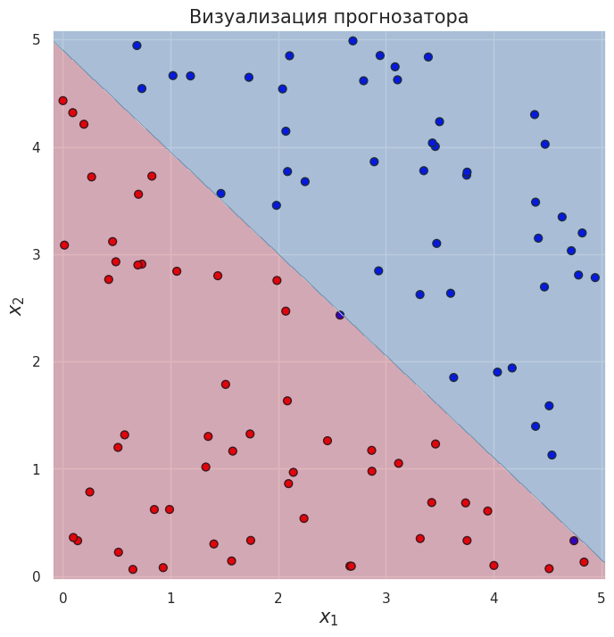

```python
plot_separating_surface(X, Y, clf)
```

### **Вопрос 3** (2 балла)

Придумайте, сгенерируйте и визуализируйте пример, в котором логистическая регрессия будет плохо классифицировать данные.

**Ваш ответ здесь**

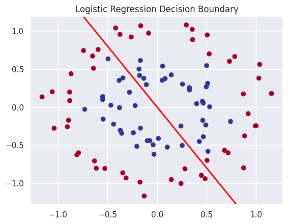

```python
#Ваш ответ здесь
import numpy as np
import matplotlib.pyplot as plt
from sklearn.datasets import make_circles
from sklearn.linear_model import LogisticRegression

# Создаем данные с двумя концентрическими кругами
X, y = make_circles(n_samples=100, factor=0.5, noise=0.1, random_state=42)

# Обучаем логистическую регрессию
clf = LogisticRegression()
clf.fit(X, y)

# Визуализируем данные и решающую границу логистической регрессии
plt.scatter(X[:, 0], X[:, 1], c=y, cmap=plt.cm.RdYlBu)
ax = plt.gca()
xlim = ax.get_xlim()
ylim = ax.get_ylim()

# Создаем сетку для визуализации решающей границы
xx, yy = np.meshgrid(np.linspace(xlim[0], xlim[1], 100), np.linspace(ylim[0], ylim[1], 100))
Z = clf.decision_function(np.c_[xx.ravel(), yy.ravel()])
Z = Z.reshape(xx.shape)

# Визуализируем решающую границу
plt.contour(xx, yy, Z, levels=[0], linewidths=2, colors='red')
plt.title('Logistic Regression Decision Boundary')
plt.show()
```

Представьте, что в одном из наших модельных примеров произошла ошибка, данные были испорчены, и теперь у нас вместо $100$ разных сэмплов — $100$ копий одного сэмпла. Например, так.

```python
X1 = []
X2 = []

for i in range(100):
    np.random.seed(1)
    x1 = np.random.uniform(0, 5)
    x2 = np.random.uniform(0, 5)
    X1.append(x1)
    X2.append(x2)

X1 = np.array(X1)
X2 = np.array(X2)
X = np.hstack((X1[:, None], X2[:, None]))

Y = []

for i in range(100):
    p = 1 / (1 + np.exp(-(X1[i] + X2[i] - 5)))
    y = np.random.choice([0, 1], p = [1 - p, p])
    Y.append(y)

Y = np.array(Y)
```

### **Вопрос 4** (1 балл)

Почему в этом коде генерируется $100$ одинаковых примеров, хотя используется random?

*Ваш ответ здесь* Проблема в том, что в цикле генерации данных внутри цикла установлен одинаковый seed (значение np.random.seed(1)), что приводит к тому, что при каждой итерации генератор случайных чисел сбрасывается в одно и то же начальное состояние. Таким образом, при каждой итерации цикла генерируются одни и те же случайные числа 100 раз

Поскольку все записи у нас идентичны, то каждому объекту обучающей выборки логистическая регрессия предскажет одинаковую вероятность принадлежности к классу $1$.

### **Вопрос 5** (2 балла)

Какую вероятность принадлежности к классу $1$ предскажет логистическая регрессия в этом случае?

*Замечание* В качестве ответа подразумевается некий общий способ получения этого числа помимо прямого обучения логистической регрессии.

*Ваш ответ здесь* вероятность принадлежности к классу 1 может быть рассчитана следующим образом:

Пусть P(Y=1) - Предсказание логистической регрессии для сэмпла, используемая в логистической регрессии:

$P(Y=1)= \beta _{0} + \beta _{1} X _1 + \beta _{2} X _2$

где $\beta_{0}, \beta_{1}, \beta_{2}$ - параметры, полученные в результате обучения логистической регрессии, а $X_1, X_2 $ - признаки.

$ P(Y=1) = \frac{1}{1 + e^{-(\beta_0 + \beta_1X + \beta_2X)}} $

$ P(Y=1) = \frac{1}{1 + e^{-X(\beta_0 + \beta_1 + \beta_2)}} $

Теперь, чтобы узнать вероятность, мы можем использовать параметры ( \beta_0, \beta_1, \beta_2 ) из нашей логистической регрессии. Однако, у нас в коде нет явного обучения модели, поэтому нужно предположить значения параметров.

Теперь мы можем подставить значения и вычислить вероятность:

$ P(Y=1) = \frac{1}{1 + e^{-(5 + 2(X_1 + X_2))}} $

Теперь, если подставить ( X_1 = X_2 ), мы получим:

$ P(Y=1) = \frac{1}{1 + e^{-(5 + 2 \cdot X)}} $

Таким образом, это будет значение вероятности принадлежности к классу 1 для данного сэмпла.

```python
from sklearn.linear_model import LogisticRegression

results = []
constants = [1e-10, 1e-9, 1e-8, 1e-7, 1e-6, 1e-5, 1e-4, 1e-3, 1e-2, 1e-1, 1]

for C in constants:
    clf = LogisticRegression(C=C, penalty='l1', solver='liblinear')
    clf.fit(X, Y)
    pred = clf.predict_proba(X)[0, 1]
    results.append(pred)

expected_value = Y.sum() / Y.shape[0]
print(results)
```

```
[0.5, 0.5, 0.5, 0.5, 0.5, 0.5, 0.5, 0.5, 0.5, 0.6122347356185366, 0.6372234735584814]
```

## Обучение на реальных данных

Рассмотрим набор данных от метеорологической службы одной страны. В нём требуется предсказать, будет ли дождь на следующий день.

Для начала, скачаем данные

```python
!gdown 1AgUMxgMK-eRjzthevCk9g-J_s2vpBFpe
```

```
Downloading...
From: https://drive.google.com/uc?id=1AgUMxgMK-eRjzthevCk9g-J_s2vpBFpe
To: /content/weatherAUS.csv
100% 14.1M/14.1M [00:00<00:00, 29.8MB/s]
```

```python
df = pd.read_csv("/content/weatherAUS.csv")
df.head(5)
```

|  | Date | Location | MinTemp | MaxTemp | Rainfall | Evaporation | Sunshine | WindGustDir | WindGustSpeed | WindDir9am | ... | Humidity9am | Humidity3pm | Pressure9am | Pressure3pm | Cloud9am | Cloud3pm | Temp9am | Temp3pm | RainToday | RainTomorrow |
| --- | --- | --- | --- | --- | --- | --- | --- | --- | --- | --- | --- | --- | --- | --- | --- | --- | --- | --- | --- | --- | --- |
| 0 | 2008-12-01 | Albury | 13.4 | 22.9 | 0.6 | NaN | NaN | W | 44.0 | W | ... | 71.0 | 22.0 | 1007.7 | 1007.1 | 8.0 | NaN | 16.9 | 21.8 | No | No |
| 1 | 2008-12-02 | Albury | 7.4 | 25.1 | 0.0 | NaN | NaN | WNW | 44.0 | NNW | ... | 44.0 | 25.0 | 1010.6 | 1007.8 | NaN | NaN | 17.2 | 24.3 | No | No |
| 2 | 2008-12-03 | Albury | 12.9 | 25.7 | 0.0 | NaN | NaN | WSW | 46.0 | W | ... | 38.0 | 30.0 | 1007.6 | 1008.7 | NaN | 2.0 | 21.0 | 23.2 | No | No |
| 3 | 2008-12-04 | Albury | 9.2 | 28.0 | 0.0 | NaN | NaN | NE | 24.0 | SE | ... | 45.0 | 16.0 | 1017.6 | 1012.8 | NaN | NaN | 18.1 | 26.5 | No | No |
| 4 | 2008-12-05 | Albury | 17.5 | 32.3 | 1.0 | NaN | NaN | W | 41.0 | ENE | ... | 82.0 | 33.0 | 1010.8 | 1006.0 | 7.0 | 8.0 | 17.8 | 29.7 | No | No |

5 rows × 23 columns

### **Вопрос 6** (1 балл)

Что это за страна? Подсказка: жители этой страны воспользовались бы методом tail вместо head :)

*Ваш ответ здесь* Австралия

Извлечём немного информации из набора данных

```python
df.shape
```

```
(145460, 23)
```

```python
df.columns
```

```
Index(['Date', 'Location', 'MinTemp', 'MaxTemp', 'Rainfall', 'Evaporation',
       'Sunshine', 'WindGustDir', 'WindGustSpeed', 'WindDir9am', 'WindDir3pm',
       'WindSpeed9am', 'WindSpeed3pm', 'Humidity9am', 'Humidity3pm',
       'Pressure9am', 'Pressure3pm', 'Cloud9am', 'Cloud3pm', 'Temp9am',
       'Temp3pm', 'RainToday', 'RainTomorrow'],
      dtype='object')
```

Внимательно приглядимся к столбцам. Напомним, что мы предсказываем значение RainTomorrow. Давайте посмотрим, на этот столбец

```python
df['RainTomorrow'].unique()
```

```
array(['No', 'Yes', nan], dtype=object)
```

Целевая переменная содержит неопределённые значения! Их нужно удалить из всей выборки. Также, переименуем 'Yes' и 'No' в $1$ и $0$.

```python
df = df[df['RainTomorrow'] == df['RainTomorrow']]
df['RainTomorrow'].unique()
```

```
array(['No', 'Yes'], dtype=object)
```

```python
df['RainTomorrow'] = df['RainTomorrow'].map({'Yes': 1., 'No': 0.})
df['RainToday'] = df['RainToday'].map({'Yes': 1., 'No': 0.})
```

```python
print(df.shape)
```

```
(142193, 23)
```

Объектов стало чуть-чуть поменьше. Давайте выведем немного информации о них

```python
df.info()
```

```
<class 'pandas.core.frame.DataFrame'>
Int64Index: 142193 entries, 0 to 145458
Data columns (total 23 columns):
 #   Column         Non-Null Count   Dtype
---  ------         --------------   -----
 0   Date           142193 non-null  object
 1   Location       142193 non-null  object
 2   MinTemp        141556 non-null  float64
 3   MaxTemp        141871 non-null  float64
 4   Rainfall       140787 non-null  float64
 5   Evaporation    81350 non-null   float64
 6   Sunshine       74377 non-null   float64
 7   WindGustDir    132863 non-null  object
 8   WindGustSpeed  132923 non-null  float64
 9   WindDir9am     132180 non-null  object
 10  WindDir3pm     138415 non-null  object
 11  WindSpeed9am   140845 non-null  float64
 12  WindSpeed3pm   139563 non-null  float64
 13  Humidity9am    140419 non-null  float64
 14  Humidity3pm    138583 non-null  float64
 15  Pressure9am    128179 non-null  float64
 16  Pressure3pm    128212 non-null  float64
 17  Cloud9am       88536 non-null   float64
 18  Cloud3pm       85099 non-null   float64
 19  Temp9am        141289 non-null  float64
 20  Temp3pm        139467 non-null  float64
 21  RainToday      140787 non-null  float64
 22  RainTomorrow   142193 non-null  float64
dtypes: float64(18), object(5)
memory usage: 26.0+ MB
```

Как видим, у нас есть 17 признаков имеющих вещественные значения (вещественные признаки), и 5 признаков типа object (категориальные признаки). Для них требуется отдельная предобработка. Пока разобьём выборку на обучающую и тестовую.

```python
from sklearn.model_selection import train_test_split
```

[figure not shown]

```python
y = df.RainTomorrow
X = df.drop(columns=["RainTomorrow"])

X_train, X_test, y_train, y_test = train_test_split(X, y, test_size=0.3, random_state=2021)
```

```python
X_train.shape
```

```
(99535, 22)
```

#### Вещественные признаки

Как вы могли заметить, среди вещественных и категориальных признаков есть пропущенные значения. В случае с вещественными признаками, пропущенные значения заполняют средним, медианой, нулём или даже пытаются предсказывать по другим признакам. Мы заполним медианой

```python
numeric_data = X_train.select_dtypes([np.number])
numeric_data_median = numeric_data.median()
numeric_features = numeric_data.columns
X_train = X_train.fillna(numeric_data_median)
X_test = X_test.fillna(numeric_data_median)
```

```python
len(numeric_features)
```

```
17
```

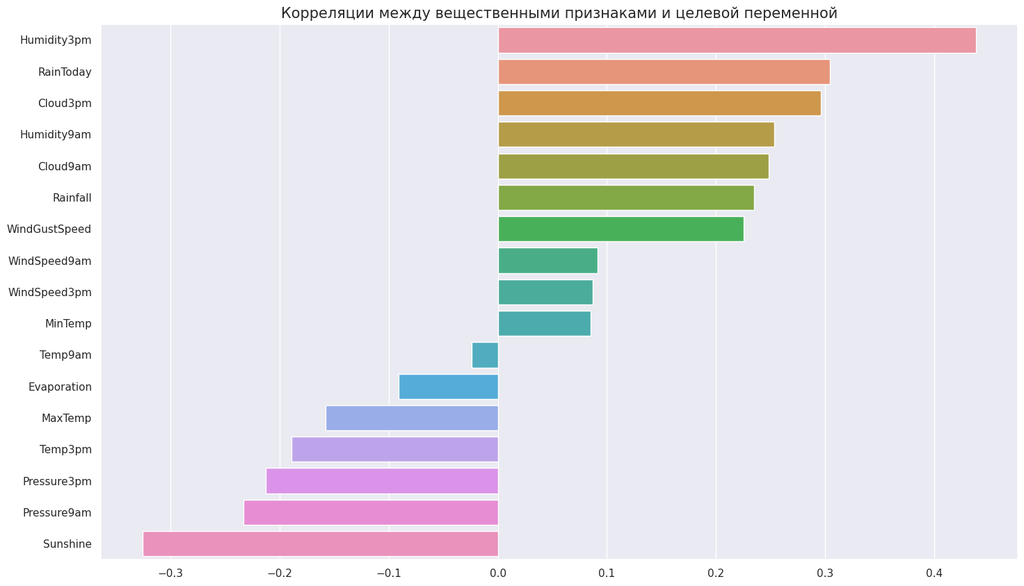

```python
correlations = X_train[numeric_features].corrwith(y_train).sort_values(ascending=False)
plot = sns.barplot(y=correlations.index, x=correlations)
plot.set_title("Корреляции между вещественными признаками и целевой переменной", size=15)
plot.figure.set_size_inches(17, 10)
```

### **Вопрос 7** (2 балла)

Попробуйте объяснить для каких-нибудь признаков получившиеся значения корреляции (почему для одних эти значения высокие, а для других низкие)?

*Ваш ответ здесь* Между RainToday и целевой переменной высокая корреляция, потому что если сегодня дождь, то с очень высокой вероятностью и завтра будет дождь. И низкая корреляция между целевым признаком и Temp9am, потому что температура и наличие дождя завтра не очень сильно коррелируют.

Дополнительно визуализируем признаки Sunshine и Humidity3pm. Библиотека seaborn предоставляет график swarmplot, который в отличие от scatterplot старается разместить на графике как можно больше точек, так чтобы они не пересекались, уложившись при этом в заданную ширину.

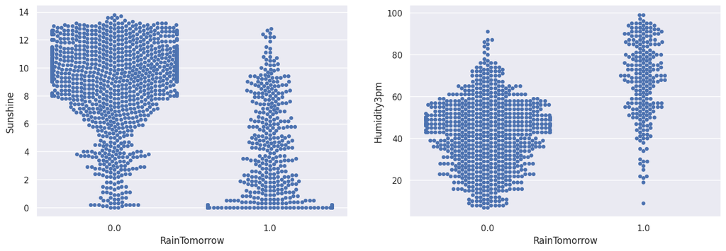

```python
fig, axs = plt.subplots(figsize=(16, 5), nrows=1, ncols=2)
_ = sns.swarmplot(x="RainTomorrow", y="Sunshine", data=df.head(10000), ax=axs[0])
_ = sns.swarmplot(x="RainTomorrow", y="Humidity3pm", data=df.head(1000), ax=axs[1])
```

Для оценки качества классификации воспользуемся реализованными в sklearn logloss и ROC AUC. ROC AUC является метрикой по умолчанию для бинарной классификации, поскольку очень устойчива к несбалансированности классов. Подробнее про неё можно прочитать https://alexanderdyakonov.wordpress.com/2017/07/28/auc-roc-площадь-под-кривой-ошибок/ . Обучим логистическую регрессию на вещественных признаках, не подбирая константу регуляризации

```python
from sklearn.metrics import log_loss, roc_auc_score
```

```python
model = LogisticRegression(solver='lbfgs', max_iter=1000)
model.fit(X_train[numeric_features], y_train)
```

```
LogisticRegression(max_iter=1000)
```

```python
y_pred = model.predict_proba(X_test[numeric_features])[:, 1]
y_train_pred = model.predict_proba(X_train[numeric_features])[:, 1]

print("Test logloss = %.4f" % log_loss(y_test, y_pred))
print("Train logloss = %.4f" % log_loss(y_train, y_train_pred))
print("Test roc auc score = %.4f" % roc_auc_score(y_test, y_pred))
print("Train roc auc score = %.4f" % roc_auc_score(y_train, y_train_pred))
```

```
Test logloss = 0.3650
Train logloss = 0.3689
Test roc auc score = 0.8588
Train roc auc score = 0.8570
```

### **Вопрос 8** (2 балла)

Сколько итераций понадобилось для обучения логистической регрессии?

*Ваш ответ* 637 итераций

```python
#Ваш ответ
print('Количество итераций: ', model.n_iter_)
```

```
Количество итераций:  [637]
```

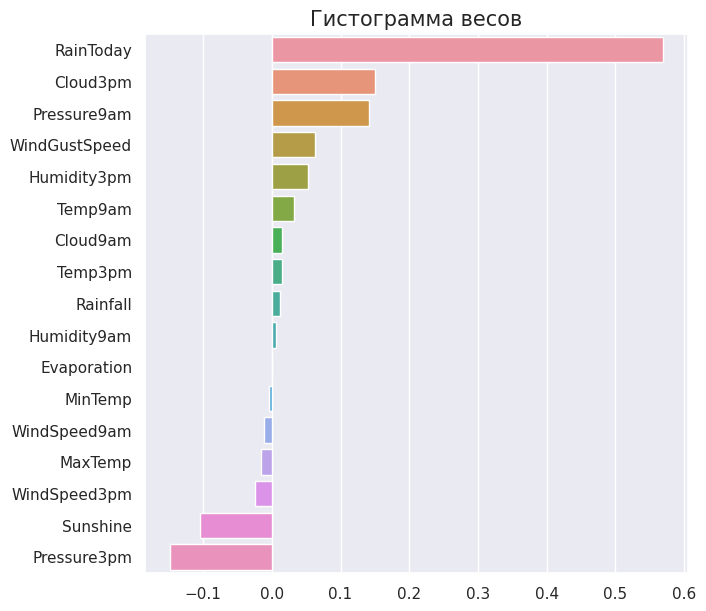

```python
plt.figure(figsize=(7, 7))
sorted_weights = sorted(zip(model.coef_[0], numeric_features), reverse=True)
weights = [x[0] for x in sorted_weights]
features = [x[1] for x in sorted_weights]
_ = sns.barplot(y=features, x=weights).set_title("Гистограмма весов", size=15)
```

Если приглядеться к весам, то можно увидеть, что между корреляциями признаков с целевой переменной и значением соответствующих весов мало общего. Чтобы это предотвратить, будем масштабировать наши признаки перед обучением модели. Это, среди, прочего, сделает нашу регуляризацию более честной: теперь все признаки будут регуляризоваться в равной степени.

```python
from sklearn.preprocessing import StandardScaler

scaler = StandardScaler()
X_train_scaled = scaler.fit_transform(X_train[numeric_features])
X_test_scaled = scaler.transform(X_test[numeric_features])
```

```python
model = LogisticRegression(solver='lbfgs', max_iter=1000)
model.fit(X_train_scaled, y_train)
```

```
LogisticRegression(max_iter=1000)
```

### **Вопрос 9** (2 балла)

А сколько итераций потребовалось теперь? Как это связано с модельными примерами, на которых мы разбирали разные методы оптимизации?

*Ваш ответ* Потребовалось 33 итерации. Веса стали "симметричнее", то есть они стали больше соответствовать корреляциям, которые были вычислены выше.

```python
#Ваш ответ
print('Количество итераций: ', model.n_iter_)
```

```
Количество итераций:  [33]
```

```python
y_pred = model.predict_proba(X_test_scaled)[:, 1]
y_train_pred = model.predict_proba(X_train_scaled)[:, 1]

print("Test logloss = %.4f" % log_loss(y_test, y_pred))
print("Train logloss = %.4f" % log_loss(y_train, y_train_pred))
print("Test roc auc score = %.4f" % roc_auc_score(y_test, y_pred))
print("Train roc auc score = %.4f" % roc_auc_score(y_train, y_train_pred))
```

```
Test logloss = 0.3592
Train logloss = 0.3636
Test roc auc score = 0.8646
Train roc auc score = 0.8625
```

### **Вопрос 10** (2 балла)

Сравните получившееся качество с качеством до нормализации. Объясните, почему оно изменилось, хотя мы применяли линейную модель к линейно преобразованным признакам? Могло ли качество измениться в другую сторону?

*Ваш ответ*

Качество до нормализации: Test logloss = 0.3650, Train logloss = 0.3689, Test roc auc score = 0.8588, Train roc auc score = 0.8570.

Качество после нормализации: Test logloss = 0.3592, Train logloss = 0.3636, Test roc auc score = 0.8646, Train roc auc score = 0.8625.

Качество модели стало лучше, так как после стандартизации полагаем, что они в равной степени важны: большой разброс признак не гарантирует его важности. Регуляризация улучшила сходимость, но она по разному делала penalty разного масштаба, а это значит, что стоит применять scaling для повышения равномерности.

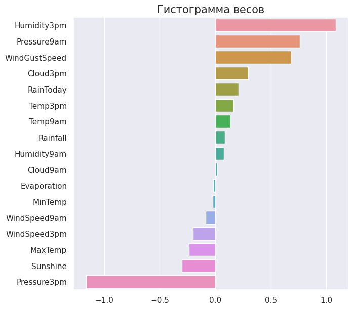

```python
plt.figure(figsize=(7, 7))
sorted_weights = sorted(zip(model.coef_[0], numeric_features), reverse=True)
weights = [x[0] for x in sorted_weights]
features = [x[1] for x in sorted_weights]
_ = sns.barplot(y=features, x=weights).set_title("Гистограмма весов", size=15)
```

### **Вопрос 11** (2 балла)

Почему даже после нормализации график не до конца похож на гистограмму корреляций?

*Ваш ответ* По формуле вероятности логистической регрессии из-за экспоненциальной зависимости в знаменателе для более важных признаков значение вероятности будет достаточно быстро стремится к большому значению, а у незначительных признаков наоборот значение будет быстрее стремится к 0. Поэтому соотношение относительных значений весов близких по важности похоже на корреляцию, а остальные сильно отличаются в относительном масштабе.

Наряду с параметрами (веса $w$, $w_0$), которые модель оптимизирует на этапе обучения, у модели есть и гиперпараметры. У нашей модели это alpha — коэффициент регуляризации. Подбирают его обычно по сетке, измеряя качество на валидационной (не тестовой) выборке или с помощью кросс-валидации. Посмотрим, как это можно сделать (заметьте, что мы перебираем alpha по логарифмической сетке, чтобы узнать оптимальный порядок величины).

### **Вопрос 12** (2 балла)

Чем отличаются валидационная и тестовая выборки?

**Ваш ответ** Тестовая выборка используется для окончательной оценки качества обученной модели. Валидационная выборка используется для подбора гиперпараметров.

```
Best C = 38.8816
```

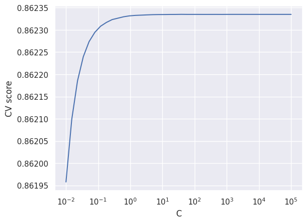

```python
from sklearn.model_selection import GridSearchCV

C = np.logspace(-2, 5, 40)
searcher = GridSearchCV(LogisticRegression(solver='lbfgs'), [{"C": C}], scoring="roc_auc", cv=10)
searcher.fit(X_train_scaled, y_train)

best_C = searcher.best_params_["C"]

print("Best C = %.4f" % best_C)

_ = plt.plot(C, searcher.cv_results_["mean_test_score"])
plt.xscale("log")
plt.xlabel("C")
plt.ylabel("CV score")
plt.show()
```

### **Вопрос 13** (2 балла)

Почему с ростом $C$ качество не падает, хотя модель должна недообучаться?

*Подсказка*: Внимательно прочитайте документацию к реализации логистической регрессии в sklearn

В sklearn коэффициент регуляризации $C$ в логистической регрессии инвертирован, то есть регуляризация уменьшается при увеличении $C$. Увеличение $C$ приводит к слабой регуляризации, что способствует более гибкой модели. Однако переобучение не происходит из-за того, что в данном случае количество объектов в обучающей выборке значительно превосходит количество признаков. Проще говоря, наличие достаточно большого объема данных компенсирует недостаток регуляризации, сохраняя при этом высокое качество модели.

### **Вопрос 14** (1 балл)

Почему мы не подбираем коэффициент регуляризации по обучающей выборке? По тестовой выборке?

*Ваш ответ* 1. Если подбирать коэффициенты по тестовой выборке, то модель будет подгоняться и адаптироваться только под эту выборку, и на тестовой выборке шанс ошибки возрастет.

1. Цель тестирования состоит в том, чтобы увидеть, как обученная модель будет работать по итогу, поэтому, если её производительность очень низкая, мы должны повторить весь процесс обучения. Продолжение настройки модели после оценки на тестовой выборке может привести к тому, что модель будет соответствовать тестовому набору, что приведет к нереалистичным / слишком оптимистичным результатам.

Попробуем обучить модель с подобранным коэффициентом регуляризации. Заодно воспользуемся удобным классом Pipeline: обучение модели часто представляется как последовательность некоторых действий с обучающей и тестовой выборками (например, сначала нужно отмасштабировать выборку (причем для обучающей выборки нужно применить метод fit, а для тестовой — transform), а затем обучить/применить модель (для обучающей fit, а для тестовой — predict). Pipeline позволяет хранить эту последовательность шагов и корректно обрабатывает разные типы выборок: и обучающую, и тестовую. Однако, если ваши модели не укладываются в использование простых fit, transform и predict, то этот класс вам не подойдёт

```python
from sklearn.pipeline import Pipeline

simple_pipeline = Pipeline([
    ('scaling', StandardScaler()),
    ('classification', LogisticRegression(solver='lbfgs', C=best_C))
])

model = simple_pipeline.fit(X_train[numeric_features], y_train)
y_pred = model.predict_proba(X_test[numeric_features])[:, 1]
print("Test logloss = %.4f" % log_loss(y_test, y_pred))
print("Test roc auc score = %.4f" % roc_auc_score(y_test, y_pred))
```

```
Test logloss = 0.3592
Test roc auc score = 0.8646
```

### **Вопрос 15** (2 балла)

Почему качество не выросло?

*Ваш ответ* Потому что коэффициент регуляризации C = 1 очень близок к best_C по качеству и мы используем округление до 4 знаков, различия начинаются с 5-ого.

Рассмотрим теперь категориальные признаки. Сразу отметим, что признак "Date" очень опасен, и лучше пока его выкинуть. Это связано с тем, что мы можем получить прямую информацию о том, будет ли завтра дождь, если текущее место и завтрашняя дата встречались где-то в обучающей выборке. Очень часто также встречаются признак наподобие "ID", которые могут содержать аналогичные утечки информации. С такими признаками всегда нужно обращаться осторожно!

```python
categorical = list(X_train.drop(columns=["Date"]).dtypes[X_train.dtypes == "object"].index)
X_train[categorical] = X_train[categorical].fillna("NotGiven")
X_test[categorical] = X_test[categorical].fillna("NotGiven")
```

Для работы с категориальными признаками нужно их как-то закодировать числами. Для этого нам понадобится заранее реализованный class MyOneHotEncoder. Вообще OneHotEncoding — самая стандартная процедура для кодирования категориальных признаков. Помимо библиотеки sklearn, встроенный OneHotEncoder есть в библиотеке pandas и называется get_dummies. Однако сегодня мы не будем пользоваться библиотечными методами:)

Если последующий код выполнятеся слишком медленно, то вероятно Вы реализовали MyOneHotEncoder без использования векторных операций из библиотеки numpy.

```python
from sklearn.compose import ColumnTransformer

column_transformer = ColumnTransformer([
    ('ohe', MyOneHotEncoder(), categorical),
    ('scaling', StandardScaler(), numeric_features)
])

pipeline = Pipeline(steps=[
    ('ohe', column_transformer),
    ('classification', LogisticRegression(solver='lbfgs', max_iter=200))
])

model = pipeline.fit(X_train.drop(columns=["Date"]), y_train)
y_pred = model.predict_proba(X_test.drop(columns=["Date"]))[:, 1]
print("Test logloss = %.4f" % log_loss(y_test, y_pred))
print("Test roc auc score = %.4f" % roc_auc_score(y_test, y_pred))
```

```
Test logloss = 0.3516
Test roc auc score = 0.8700
```

Качество немного выросло, если смотреть на ROC AUC!

Давайте попробуем счётчики.

Напомним, что счётчики преобразуют категориальный признак в три значения:

1. Доля counts объектов в обучающей выборке с таким же значением признака. $$\begin{align} successes_j(c) = \frac{1}{n} \sum_{i=1}^n [f_j(x_i) = c] \end{align}$$
2. Доля successes объектов первого класса ($y = 1$) в обучающей выборке с таким же значением признака. $$\begin{align} counts_j(c) = \frac{1}{n * counts_j(c)} \sum_{i=1}^n[f_j(x_i) = c][y_i = +1]. \end{align}$$
3. Сглаженное отношение двух предыдущих величин: $$\begin{align} p_j(c) = \frac{successes_j(c) + a}{counts_j(c) + b}, \end{align}$$

**Обратите внимание!** Если Ваша реализация счётчиков работает очень долго, то вероятнее всего, Вы плохо векторизовали код. Попробуйте использовать np.vectorize

[figure not shown]

```python
scal = StandardScaler()

enc_train = FoldCounters()
enc_train.fit(X_train[categorical], y_train)
X_train_counters = enc_train.transform(X_train[categorical])

enc_test = SimpleCounterEncoder()
enc_test.fit(X_train[categorical], y_train)
X_test_counters = enc_test.transform(X_test[categorical])

X_train_preprocessed = scal.fit_transform(np.hstack((X_train[numeric_features].to_numpy(), X_train_counters)))
X_test_preprocessed = scal.transform(np.hstack((X_test[numeric_features].to_numpy(), X_test_counters)))

model = LogisticRegression(solver="lbfgs")
model.fit(X_train_preprocessed, y_train)

y_pred = model.predict_proba(X_test_preprocessed)[:, 1]
print("Test logloss = %.4f" % log_loss(y_test, y_pred))
print("Test roc auc score = %.4f" % roc_auc_score(y_test, y_pred))
```

[output not shown]

[output not shown]

[output cut: 18 more lines]

[output not shown]

### **Вопрос 16** (2 балла)

Счётчики показывают худшее качество по AUC ROC, нежели OneHotEncoding. В чём же преимущества счётчиков?

*Ваш ответ* One-hot encoding может выдавать огромные разреженные матрицы, в то время как Counter(-ы) хранят данные досаточно компактно.

Использование счётчиков вместо OneHotEncoding может быть более предпочтительным в ситуациях, где присутствует большое количество категориальных признаков или признаки имеют много уникальных значений. One-hot кодирование в таких случаях приводит к созданию слишком большого числа новых признаков, что может вызывать вычислительные трудности. Счётчики, напротив, представляют собой числовые значения, отражающие статистику по каждой категории, что может помочь сократить размерность данных и улучшить производительность модели.

**Выводы** Во второй части задания по линейным моделям мы должны были узнать: .

1. Зачем нужно нормализовать данные.
2. Как работать с вещественными и категориальными признаками.
3. Как интерпретировать результат обучения линейной модели, опираясь на описание обучающих данных

### Бонусное задание (2 балла)

Вставьте мем или красивую картинку связанные с чем-то из:

1. Страна, данные о которой мы анализировали
2. Линейные модели
3. Погода
4. Динозавры

[figure not shown]